# 成长类因子

| date | fname | Obs | NAs | min | max | mean | median | sd | skewness | kurtosis |
| --- | --- | --- | --- | --- | --- | --- | --- | --- | --- | --- |
| 2011-07-29 | scale | 1948 | 0 | -2.11 | 1.84 | -0.09 | 0.00 | 0.93 | -0.12 | 0.42 |
| 2011-07-29 | scale_ind | 1948 | 0 | -2.82 | 2.68 | -0.07 | 0.00 | 0.93 | -0.11 | 0.55 |
| 2011-07-29 | scale_indfct | 1948 | 0 | -2.82 | 2.88 | -0.05 | 0.00 | 0.93 | -0.10 | 0.59 |
| 2011-07-29 | reg_indfct | 1948 | 0 | -2.39 | 2.19 | -0.05 | 0.01 | 0.93 | -0.08 | 0.43 |
| 2013-05-31 | scale | 2217 | 0 | -2.16 | 1.81 | -0.11 | 0.00 | 0.86 | -0.42 | 0.96 |
| 2013-05-31 | scale_ind | 2217 | 0 | -3.63 | 2.75 | -0.10 | 0.00 | 0.86 | -0.40 | 1.53 |
| 2013-05-31 | scale_indfct | 2217 | 0 | -3.63 | 2.92 | -0.09 | 0.00 | 0.86 | -0.30 | 1.51 |
| 2013-05-31 | reg_indfct | 2217 | 0 | -2.76 | 2.85 | -0.06 | 0.05 | 0.86 | -0.23 | 1.19 |
| 2015-05-29 | scale | 2095 | 0 | -1.89 | 1.80 | -0.01 | 0.00 | 0.86 | 0.09 | 0.71 |
| 2015-05-29 | scale_ind | 2095 | 0 | -2.33 | 3.04 | 0.02 | 0.00 | 0.86 | 0.20 | 1.07 |
| 2015-05-29 | scale_indfct | 2095 | 0 | -2.86 | 3.12 | 0.03 | 0.00 | 0.86 | 0.23 | 1.02 |
| 2015-05-29 | reg_indfct | 2095 | 0 | -2.23 | 3.01 | 0.03 | 0.01 | 0.86 | 0.21 | 0.91 |
| 2015-06-30 | scale | 2126 | 0 | -1.88 | 1.78 | -0.02 | 0.00 | 0.86 | 0.04 | 0.64 |
| 2015-06-30 | scale_ind | 2126 | 0 | -2.60 | 2.55 | 0.02 | 0.00 | 0.86 | 0.17 | 1.01 |
| 2015-06-30 | scale_indfct | 2126 | 0 | -2.72 | 2.91 | 0.03 | 0.00 | 0.87 | 0.17 | 1.04 |
| 2015-06-30 | reg_indfct | 2126 | 0 | -2.36 | 2.78 | 0.03 | 0.01 | 0.87 | 0.19 | 0.87 |
| 2017-09-29 | scale | 2787 | 0 | -1.99 | 1.74 | -0.07 | 0.00 | 0.87 | -0.13 | 0.70 |
| 2017-09-29 | scale_ind | 2787 | 0 | -3.00 | 2.98 | -0.06 | 0.00 | 0.87 | -0.12 | 1.00 |
| 2017-09-29 | scale_indfct | 2787 | 0 | -3.06 | 3.14 | -0.04 | 0.00 | 0.87 | -0.04 | 1.12 |
| 2017-09-29 | reg_indfct | 2787 | 0 | -2.97 | 2.52 | -0.03 | 0.01 | 0.87 | -0.13 | 0.81 |

不同refine方式下因子IC图

```
## The guessed factorNames are: scale,scale_ind,scale_indfct,reg_indfct.
```

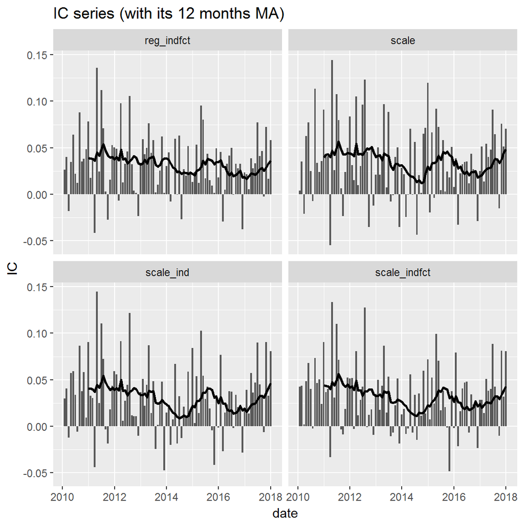

```r
MF.chart.IC(mTSFR = mtsfr,facet_by = 'fname')
```

不同refine方式下因子分组多空收益图

```
## The guessed factorNames are: scale,scale_ind,scale_indfct,reg_indfct.
```

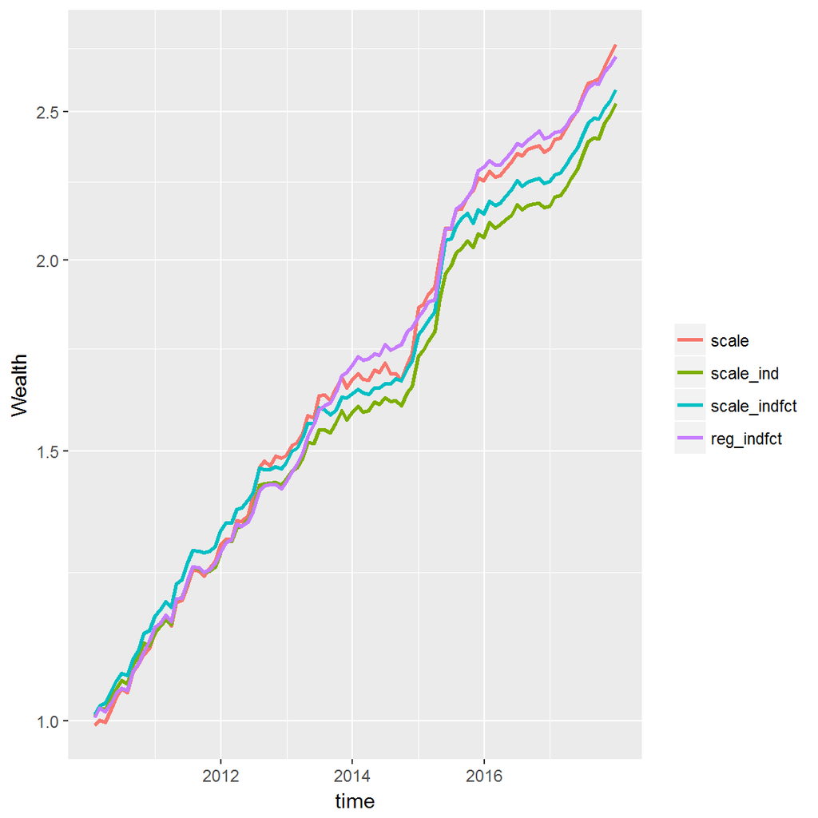

```r
MF.chart.Ngroup.spread(mTSFR = mtsfr, N = 5)
```

不同refine方式下因子分组多空相对收益图

```
## The guessed factorNames are: scale,scale_ind,scale_indfct,reg_indfct.
```

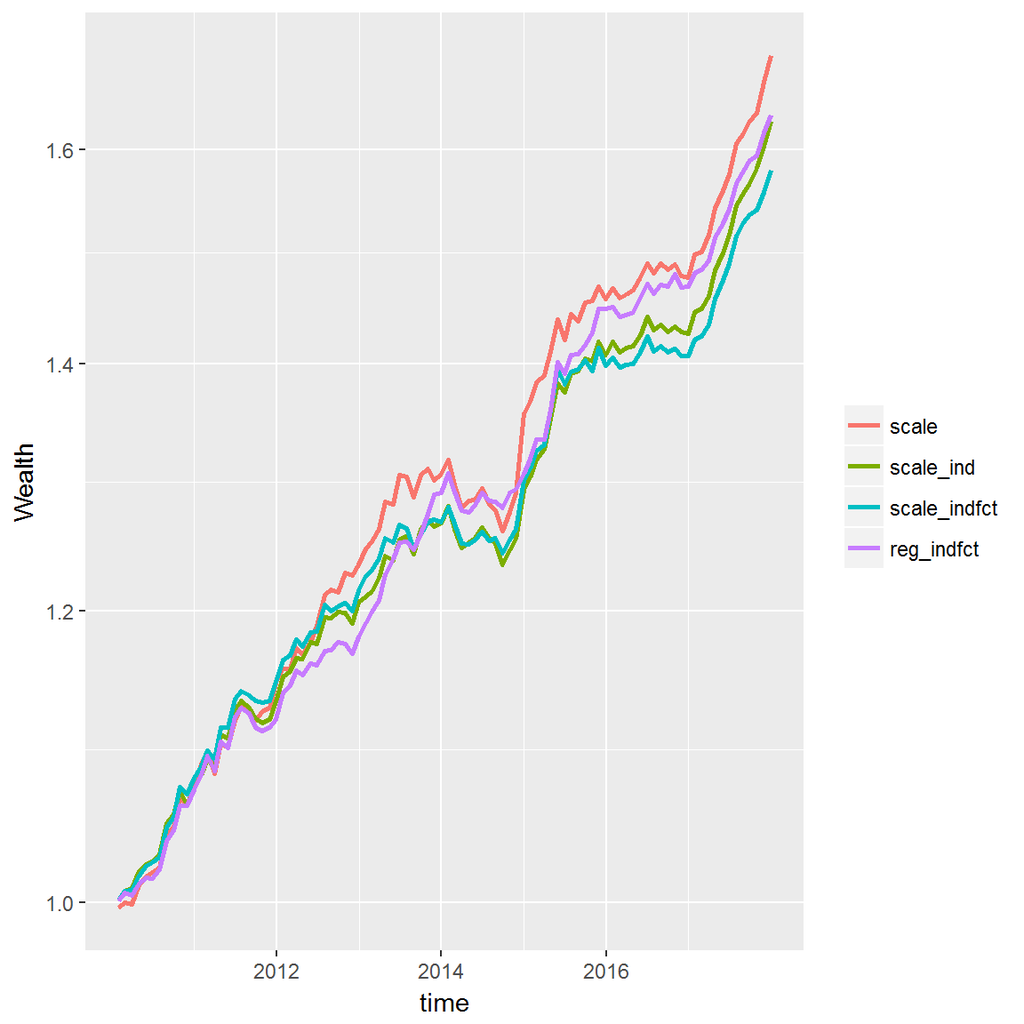

```r
MF.chart.Ngroup.spread(mTSFR = mtsfr, N = 5,rtn_type = "long-univ")
```

不同refine方式下因子IC和分组收益统计表

```r
table_ <- MC.table.ICandNgroup(mTSF2TSFs(mtsfr), N = 5)
```

```
## The guessed factorNames are: scale,scale_ind,scale_indfct,reg_indfct.
```

```r
table_ <- table_[,tablenames]
kable(table_,digits = 2)
```

|  | IC_mean | IC_IR | IC_hitRatio | Annualized Return | Annualized Sharpe(Rf=0%) | Worst Drawdown | Beta | Size |
| --- | --- | --- | --- | --- | --- | --- | --- | --- |
| scale | 0.04 | 0.88 | 0.81 | 0.14 | 2.70 | 0.02 | -0.02 | 50.05 |
| scale_ind | 0.03 | 0.85 | 0.80 | 0.12 | 2.89 | 0.01 | -0.02 | 33.50 |
| scale_indfct | 0.03 | 0.95 | 0.78 | 0.13 | 2.95 | 0.01 | -0.01 | 24.65 |
| reg_indfct | 0.03 | 0.99 | 0.88 | 0.13 | 3.29 | 0.01 | 0.01 | -8.87 |

```r
table_ <- data.frame(factorName=fname_,refinePar=rownames(table_),table_,row.names = NULL,stringsAsFactors = FALSE)
tablestats <- rbind(tablestats,table_)
```

## 7、因子F_rank_chg

```r
fname_ <- fnames[7]
tsfr <- tsfrs_raw[[fname_]]
mtsfr <- factor_refine_MF(tsfr,refinePars)
```

```
## Function getTSF: getting the factorscore ....
## Function getTSF: getting the factorscore ....
```

```r
mtsfrrefine <- rbind(mtsfrrefine,data.frame(mtsfr,fname=fname_))
```

因子NA比例

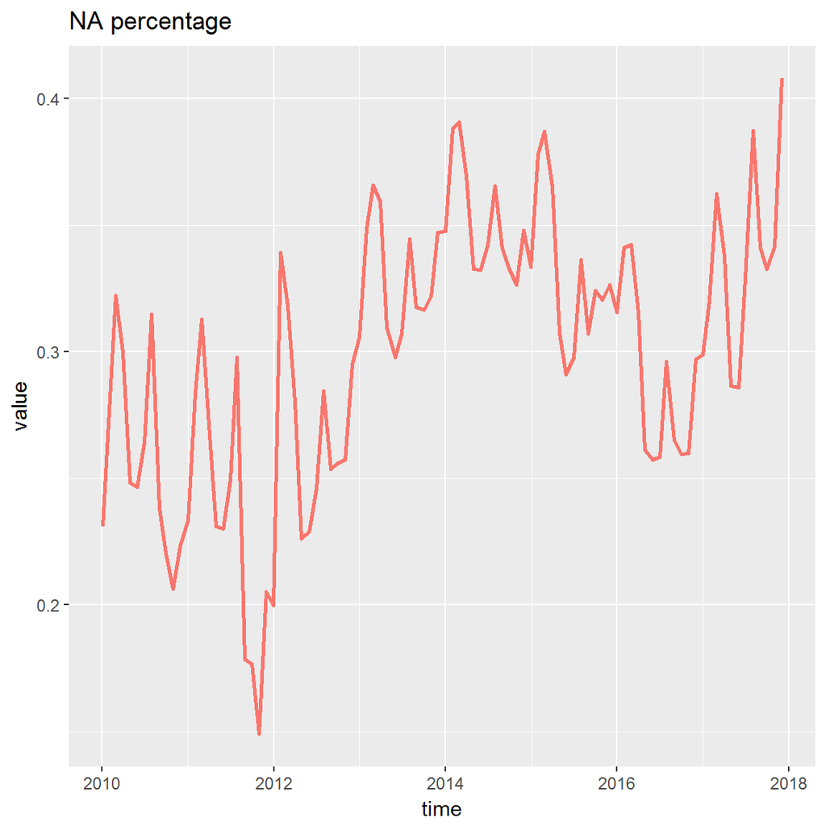

```r
chart.Fct_NA(tsfr)
```

因子原始得分直方图

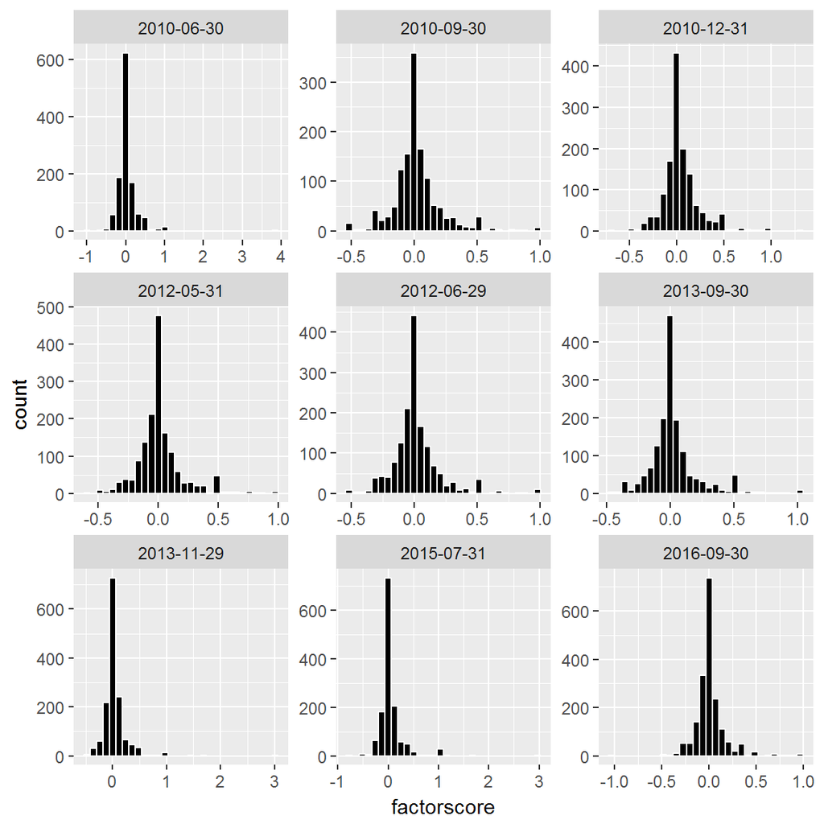

```r
chart.Fct_hist(tsfr,9)
```

不同refine方式下因子得分分布直方图

```
## The guessed factorNames are: scale,scale_ind,scale_indfct,reg_indfct.
```

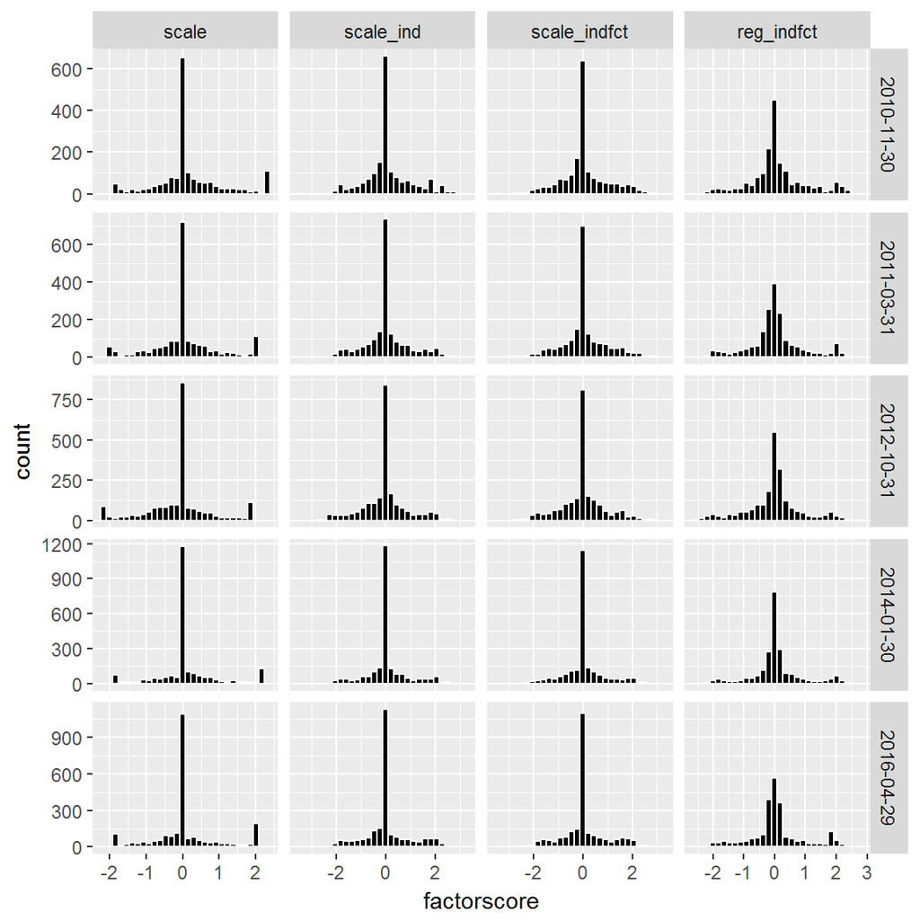

```r
MF.chart.Fct_hist(mtsfr,5)
```

不同refine方式下因子得分统计表

```r
kable(MF.table.Fct_descr(mtsfr,5),digits = 2)
```

```
## The guessed factorNames are: scale,scale_ind,scale_indfct,reg_indfct.
```

| date | fname | Obs | NAs | min | max | mean | median | sd | skewness | kurtosis |
| --- | --- | --- | --- | --- | --- | --- | --- | --- | --- | --- |
| 2010-01-29 | scale | 1476 | 0 | -1.81 | 2.15 | 0.16 | 0.00 | 0.86 | 0.54 | 0.91 |
| 2010-01-29 | scale_ind | 1476 | 0 | -3.25 | 2.82 | 0.10 | 0.00 | 0.85 | 0.48 | 1.11 |
| 2010-01-29 | scale_indfct | 1476 | 0 | -3.25 | 2.82 | 0.09 | 0.00 | 0.86 | 0.35 | 0.90 |
| 2010-01-29 | reg_indfct | 1476 | 0 | -2.27 | 2.49 | 0.08 | -0.03 | 0.86 | 0.45 | 0.95 |
| 2014-04-30 | scale | 2213 | 0 | -1.86 | 2.06 | 0.09 | 0.00 | 0.82 | 0.53 | 1.33 |
| 2014-04-30 | scale_ind | 2213 | 0 | -3.05 | 3.15 | 0.09 | 0.00 | 0.82 | 0.45 | 1.52 |
| 2014-04-30 | scale_indfct | 2213 | 0 | -3.05 | 3.02 | 0.08 | 0.00 | 0.82 | 0.46 | 1.47 |
| 2014-04-30 | reg_indfct | 2213 | 0 | -2.37 | 2.55 | 0.05 | -0.03 | 0.83 | 0.46 | 1.19 |
| 2014-11-28 | scale | 2162 | 0 | -1.84 | 2.09 | 0.10 | 0.00 | 0.81 | 0.48 | 1.47 |
| 2014-11-28 | scale_ind | 2162 | 0 | -2.08 | 3.18 | 0.09 | 0.00 | 0.81 | 0.54 | 1.65 |
| 2014-11-28 | scale_indfct | 2162 | 0 | -2.68 | 3.35 | 0.09 | 0.00 | 0.80 | 0.49 | 1.71 |
| 2014-11-28 | reg_indfct | 2162 | 0 | -2.12 | 2.29 | 0.08 | -0.01 | 0.81 | 0.49 | 1.39 |
| 2015-01-30 | scale | 2223 | 0 | -1.75 | 2.19 | 0.14 | 0.00 | 0.80 | 0.70 | 1.67 |
| 2015-01-30 | scale_ind | 2223 | 0 | -2.19 | 2.86 | 0.11 | 0.00 | 0.79 | 0.75 | 1.84 |
| 2015-01-30 | scale_indfct | 2223 | 0 | -2.79 | 2.99 | 0.09 | 0.00 | 0.79 | 0.56 | 1.88 |
| 2015-01-30 | reg_indfct | 2223 | 0 | -2.21 | 2.77 | 0.09 | -0.03 | 0.80 | 0.64 | 1.68 |
| 2017-10-31 | scale | 2763 | 0 | -2.01 | 1.78 | -0.07 | 0.00 | 0.81 | -0.13 | 1.25 |
| 2017-10-31 | scale_ind | 2763 | 0 | -2.44 | 2.36 | -0.03 | 0.00 | 0.81 | -0.10 | 1.39 |
| 2017-10-31 | scale_indfct | 2763 | 0 | -3.00 | 2.67 | -0.02 | 0.00 | 0.81 | -0.02 | 1.53 |
| 2017-10-31 | reg_indfct | 2763 | 0 | -2.62 | 2.24 | -0.01 | 0.02 | 0.81 | -0.05 | 1.29 |

不同refine方式下因子IC图

```
## The guessed factorNames are: scale,scale_ind,scale_indfct,reg_indfct.
```

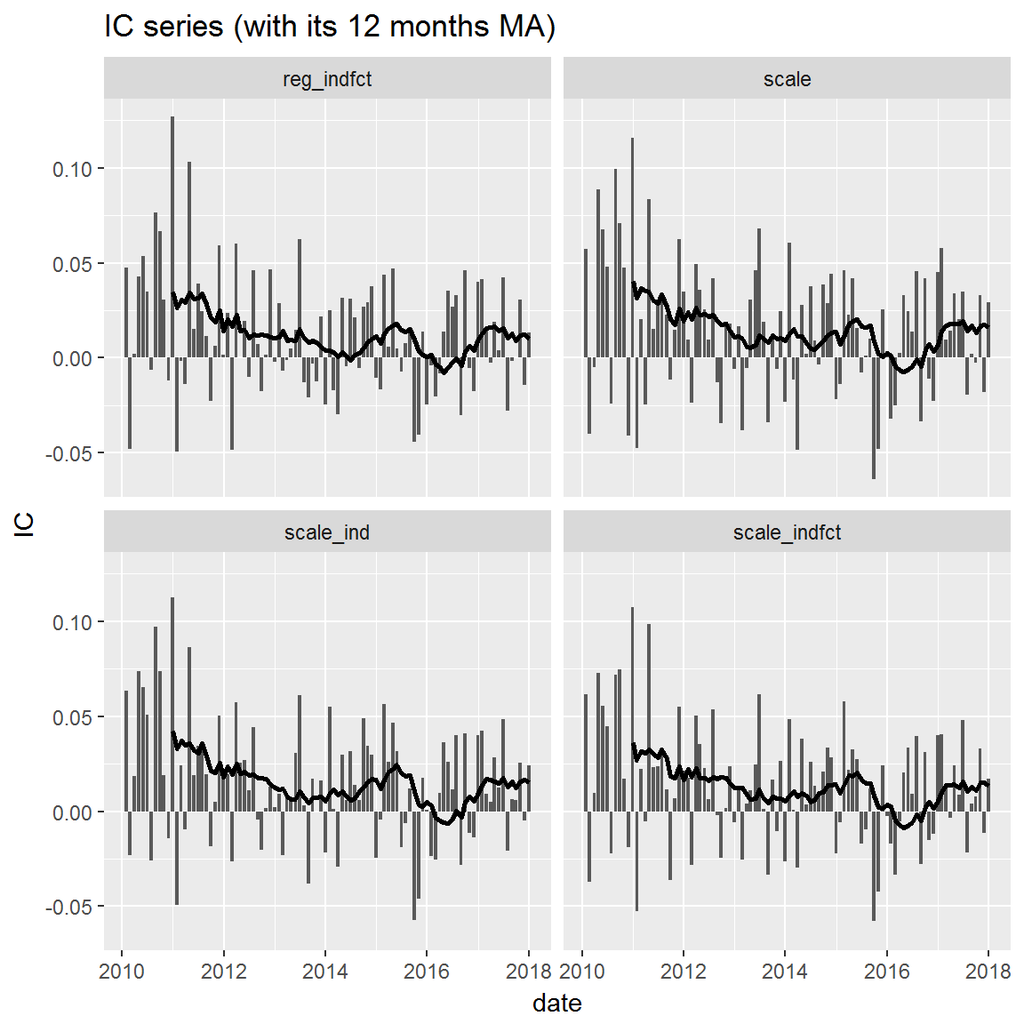

```r
MF.chart.IC(mTSFR = mtsfr,facet_by = 'fname')
```

不同refine方式下因子分组多空收益图

```
## The guessed factorNames are: scale,scale_ind,scale_indfct,reg_indfct.
```

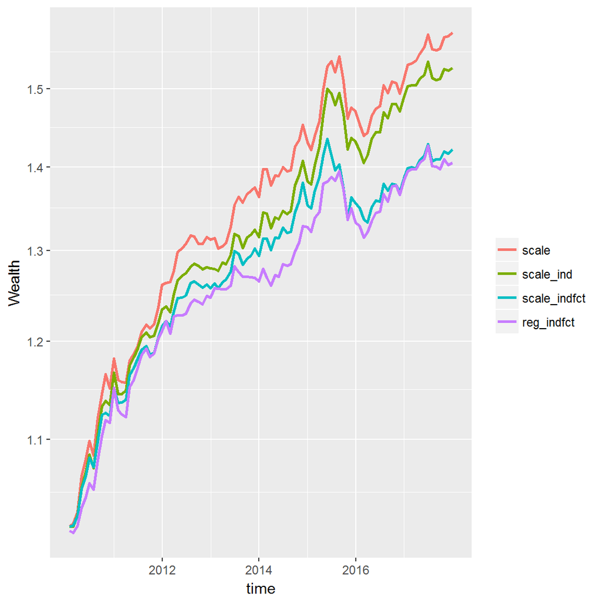

```r
MF.chart.Ngroup.spread(mTSFR = mtsfr, N = 5)
```

不同refine方式下因子分组多空相对收益图

```
## The guessed factorNames are: scale,scale_ind,scale_indfct,reg_indfct.
```

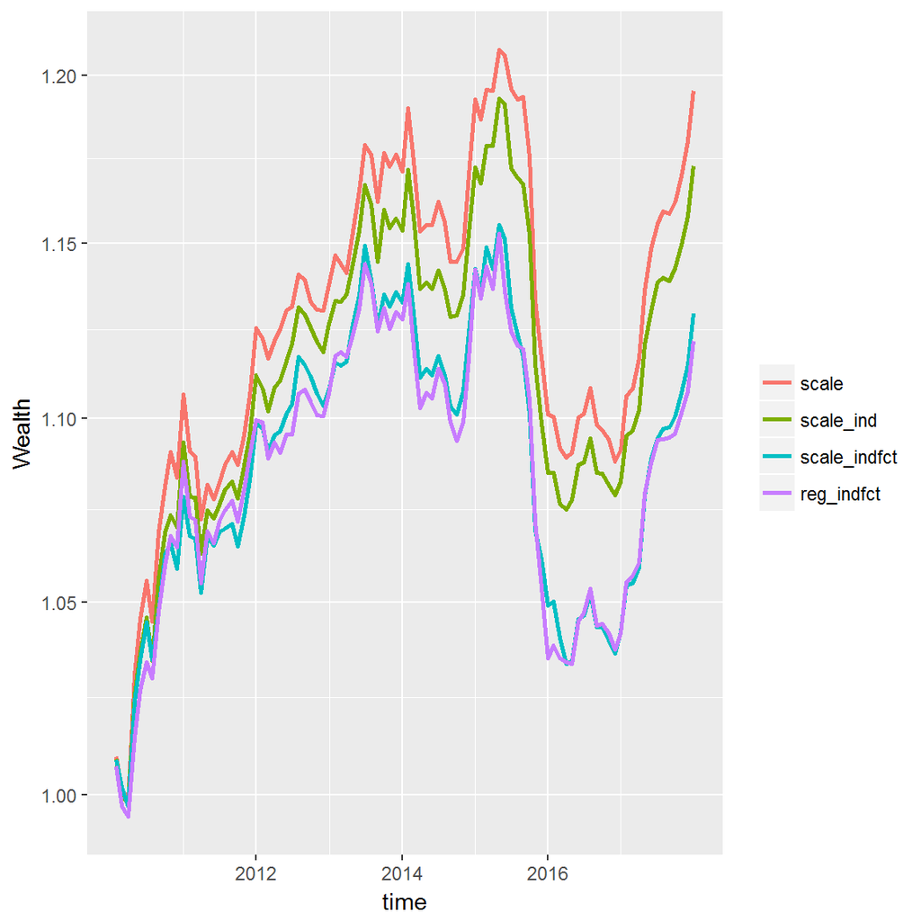

```r
MF.chart.Ngroup.spread(mTSFR = mtsfr, N = 5,rtn_type = "long-univ")
```

不同refine方式下因子IC和分组收益统计表

```r
table_ <- MC.table.ICandNgroup(mTSF2TSFs(mtsfr), N = 5)
```

```
## The guessed factorNames are: scale,scale_ind,scale_indfct,reg_indfct.
```

```r
table_ <- table_[,tablenames]
kable(table_,digits = 2)
```

|  | IC_mean | IC_IR | IC_hitRatio | Annualized Return | Annualized Sharpe(Rf=0%) | Worst Drawdown | Beta | Size |
| --- | --- | --- | --- | --- | --- | --- | --- | --- |
| scale | 0.01 | 0.43 | 0.67 | 0.06 | 1.44 | 0.07 | 0.00 | -7.43 |
| scale_ind | 0.02 | 0.48 | 0.72 | 0.05 | 1.40 | 0.06 | 0.00 | -14.38 |
| scale_indfct | 0.01 | 0.42 | 0.68 | 0.04 | 1.24 | 0.07 | 0.00 | -13.77 |
| reg_indfct | 0.01 | 0.38 | 0.59 | 0.04 | 1.27 | 0.06 | -0.01 | 26.30 |

```r
table_ <- data.frame(factorName=fname_,refinePar=rownames(table_),table_,row.names = NULL,stringsAsFactors = FALSE)
tablestats <- rbind(tablestats,table_)
```

## 8、相关性COR

```r
size <- gf.ln_mkt_cap(ts)
size <- dplyr::rename(size,ln_mkt_cap=factorscore)
mtsf <- dplyr::select(tsfr_raw,-date_end,-periodrtn)
mtsf <- dplyr::left_join(mtsf,size,by=c('date','stockID'))

mtsfrefine <- reshape2::dcast(mtsfrrefine,date+stockID~fname,value.var = 'reg_indfct')
mtsfrefine <- dplyr::left_join(mtsfrefine,size,by=c('date','stockID'))
```

原始因子的相关性图

```
## The guessed factorNames are: NP_YOY,G_MLL_Q,G_OR_Q,G_EPS_Q,G_OR_longterm,F_NP_chg,F_rank_chg,ln_mkt_cap.
```

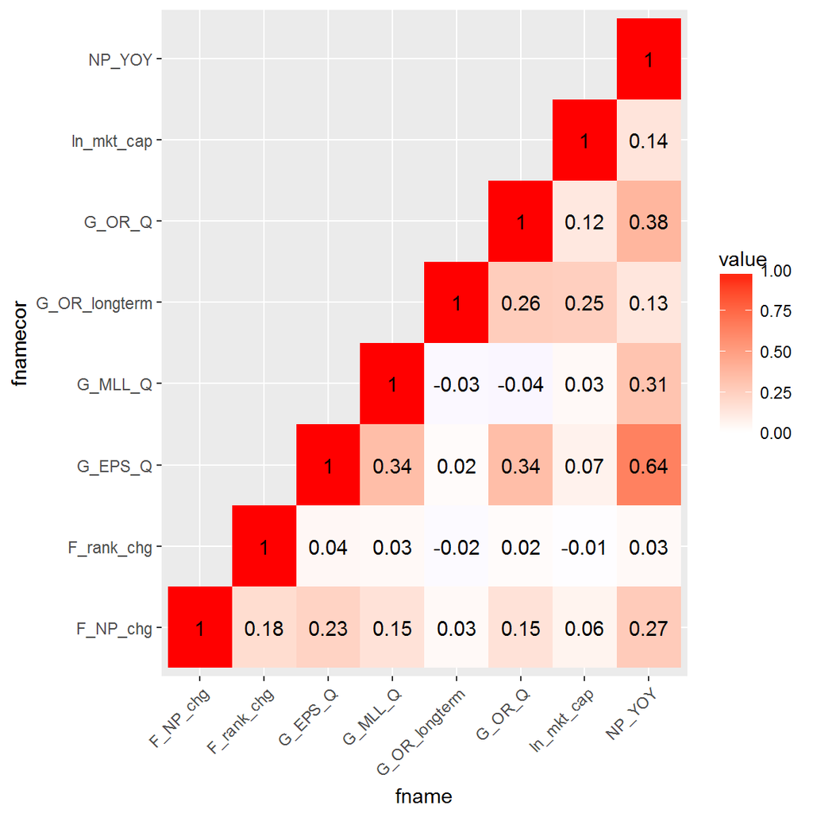

```r
MF.chart.Fct_corr(mtsf)
```

行业市值标准化后因子的相关性图

```
## The guessed factorNames are: NP_YOY,G_MLL_Q,G_OR_Q,G_EPS_Q,G_OR_longterm,F_NP_chg,F_rank_chg,ln_mkt_cap.
```

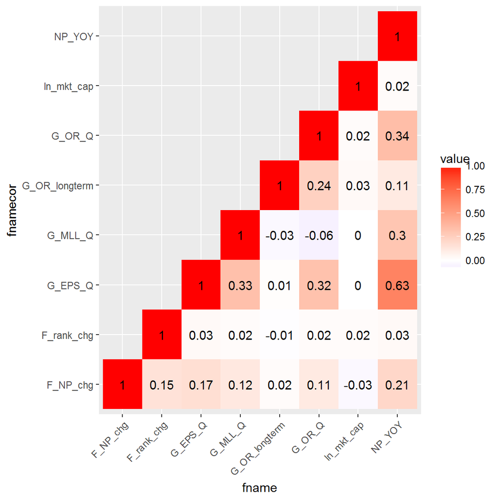

```r
MF.chart.Fct_corr(mtsfrefine)
```

## 9、SUMMARY

不同因子不同refine方式下因子IC和分组收益统计表

```r
kable(tablestats,digits = 2)
```

| factorName | refinePar | IC_mean | IC_IR | IC_hitRatio | Annualized.Return | Annualized.Sharpe.Rf.0.. | Worst.Drawdown | Beta | Size |
| --- | --- | --- | --- | --- | --- | --- | --- | --- | --- |
| NP_YOY | scale | 0.03 | 0.50 | 0.72 | 0.13 | 1.84 | 0.04 | -0.03 | 27.29 |
| NP_YOY | scale_ind | 0.03 | 0.52 | 0.74 | 0.10 | 1.80 | 0.04 | -0.04 | -13.42 |
| NP_YOY | scale_indfct | 0.03 | 0.65 | 0.77 | 0.12 | 2.25 | 0.02 | -0.02 | -25.84 |
| NP_YOY | reg_indfct | 0.04 | 0.69 | 0.79 | 0.13 | 2.24 | 0.03 | 0.00 | -33.09 |
| G_MLL_Q | scale | 0.02 | 0.50 | 0.66 | 0.08 | 1.80 | 0.04 | -0.01 | 5.15 |
| G_MLL_Q | scale_ind | 0.02 | 0.52 | 0.65 | 0.08 | 1.84 | 0.02 | -0.01 | 26.80 |
| G_MLL_Q | scale_indfct | 0.02 | 0.59 | 0.66 | 0.08 | 1.96 | 0.02 | 0.00 | 18.84 |
| G_MLL_Q | reg_indfct | 0.02 | 0.63 | 0.72 | 0.08 | 2.11 | 0.02 | -0.01 | -7.78 |
| G_OR_Q | scale | 0.03 | 0.49 | 0.68 | 0.12 | 1.47 | 0.09 | 0.04 | 28.42 |
| G_OR_Q | scale_ind | 0.03 | 0.52 | 0.68 | 0.09 | 1.52 | 0.07 | 0.01 | -20.79 |
| G_OR_Q | scale_indfct | 0.03 | 0.60 | 0.74 | 0.11 | 1.83 | 0.07 | 0.02 | -33.57 |
| G_OR_Q | reg_indfct | 0.03 | 0.64 | 0.74 | 0.11 | 1.89 | 0.05 | 0.02 | -30.47 |
| G_EPS_Q | scale | 0.03 | 0.56 | 0.69 | 0.12 | 2.09 | 0.03 | -0.03 | 25.19 |
| G_EPS_Q | scale_ind | 0.03 | 0.65 | 0.72 | 0.11 | 2.17 | 0.03 | -0.04 | 4.72 |
| G_EPS_Q | scale_indfct | 0.03 | 0.72 | 0.76 | 0.12 | 2.55 | 0.03 | -0.03 | 0.97 |
| G_EPS_Q | reg_indfct | 0.03 | 0.74 | 0.76 | 0.13 | 2.54 | 0.03 | -0.01 | -7.46 |
| G_OR_longterm | scale | 0.00 | -0.06 | 0.44 | -0.02 | -0.22 | 0.21 | -0.03 | 60.97 |
| G_OR_longterm | scale_ind | 0.00 | 0.00 | 0.45 | 0.00 | -0.05 | 0.18 | -0.06 | -46.02 |
| G_OR_longterm | scale_indfct | 0.01 | 0.20 | 0.59 | 0.04 | 0.81 | 0.08 | -0.02 | -77.81 |
| G_OR_longterm | reg_indfct | 0.01 | 0.22 | 0.59 | 0.04 | 0.74 | 0.10 | 0.01 | -179.79 |
| F_NP_chg | scale | 0.04 | 0.88 | 0.81 | 0.14 | 2.70 | 0.02 | -0.02 | 50.05 |
| F_NP_chg | scale_ind | 0.03 | 0.85 | 0.80 | 0.12 | 2.89 | 0.01 | -0.02 | 33.50 |
| F_NP_chg | scale_indfct | 0.03 | 0.95 | 0.78 | 0.13 | 2.95 | 0.01 | -0.01 | 24.65 |
| F_NP_chg | reg_indfct | 0.03 | 0.99 | 0.88 | 0.13 | 3.29 | 0.01 | 0.01 | -8.87 |
| F_rank_chg | scale | 0.01 | 0.43 | 0.67 | 0.06 | 1.44 | 0.07 | 0.00 | -7.43 |
| F_rank_chg | scale_ind | 0.02 | 0.48 | 0.72 | 0.05 | 1.40 | 0.06 | 0.00 | -14.38 |
| F_rank_chg | scale_indfct | 0.01 | 0.42 | 0.68 | 0.04 | 1.24 | 0.07 | 0.00 | -13.77 |
| F_rank_chg | reg_indfct | 0.01 | 0.38 | 0.59 | 0.04 | 1.27 | 0.06 | -0.01 | 26.30 |